# Spotify Predictive Analysis

Sujata Biradar, Aliya Alimujiang, Rui Huang

2020-12-02

# Abstract

In this analysis, we use the findings from our initial explorations done in the spotify_analysis.Rmd file and try to do clustering analysis using K-means method. We try to provide song recommendations to the user based off cluster analysis.

# Analysis

For this analysis, we will use the tidyverse to explore the tracks dataset stored in the “output” folder. The data was retrieved through Spotify API request.

```r
library(tidyverse)
library(lubridate)
#install.packages("factoextra")
#install.packages("broom")
library(factoextra)
library(broom)
library(tree)
```

```r
tracks <- read_csv("../output/tracks.csv")
artists <- read_csv("../output/artists.csv")
```

From the correlation plot in our analysis file,it shows track_popularity doesn’t have strong correlation with others any numerical variables. But we found few audio features have strong correlation with each other.

To find more interesting and undiscovered pattern in the data, we will use clustering method using the K-means.

# Data Pre-processing:

Joining tracks and artists:

```r
tracks <- tracks %>%
  mutate(duration_s = dmilliseconds(duration_ms)) %>%
  select(track_id:time_signature, duration_s, artist_id, -duration_ms)

tracks_artists <- tracks %>%
  inner_join(artists, by = 'artist_id')

# Removing duplicates if any
tracks_artists <- tracks_artists[!duplicated(tracks_artists$track_id),]
```

Transforming Variables:

```r
tracks_artists <- tracks_artists %>%
  mutate(artist_genre  = as.factor(tracks_artists$artist_genre),
         mode = as.factor(mode),
         key = as.factor(key),
         duration_min = duration_s/60)
```

Creating groups for popularity to have effective cluster analysis:

```r
tracks_artists <- tracks_artists %>%
  mutate(popularity_group = as.integer(case_when(
    ((track_popularity > 0) & (track_popularity < 30)) ~ "1",
    ((track_popularity >= 30) & (track_popularity < 60))~ "2",
    ((track_popularity >= 60) & (track_popularity < 90)) ~ "3",
    ((track_popularity >= 90) ~ "4")))
    )
table(tracks_artists$popularity_group)
```

```
##
##     1     2     3     4
##  5161 23287  8563    36
```

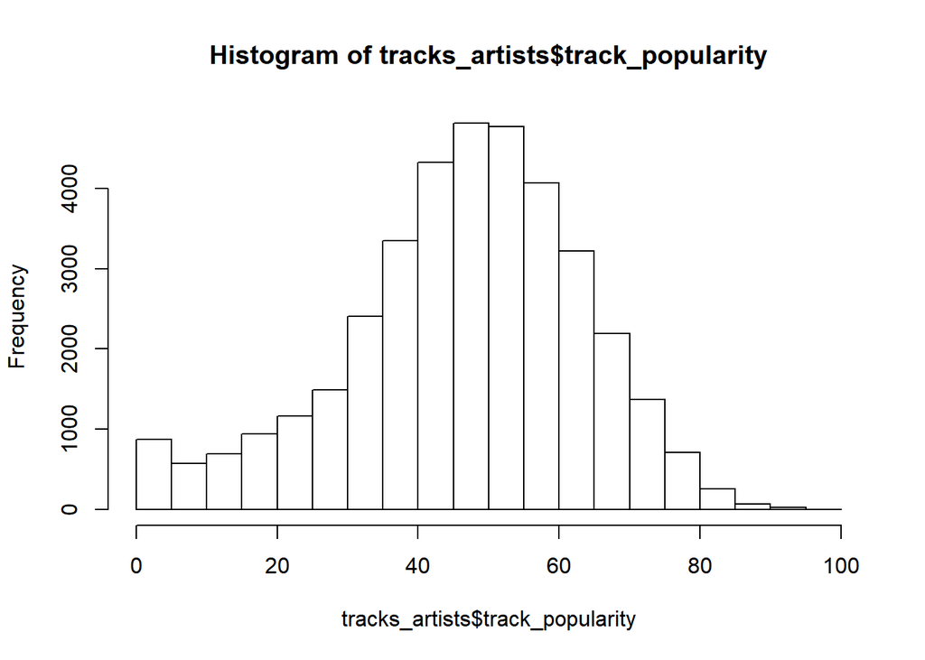

```r
hist(tracks_artists$track_popularity)
```

Next step, we will do feature scaling. Feature scaling is a method used to standardize the range of independent variables or features of data. In data processing, it is also known as data normalization and is generally performed during the data preprocessing step. Normalization is used when we want to bound our values between two numbers, typically, between [0,1] or [-1,1]. Scaling the numeric variables for cluster analysis so that the influence of variables measured on higher scales is negated.

```r
# store numeric variable names in a vector

tracks_artists1 <-
  tracks_artists%>%
  select(c(-track_popularity, -release_year, -time_signature, -artist_popularity, -total_followers, -popularity_group, -mode))

num.vars <- keep(tracks_artists1, ~class(.) == 'numeric') %>% colnames()
tracks_artists_scaled <- scale(tracks_artists1[num.vars])
summary(tracks_artists_scaled)
```

```
##   danceability          energy           loudness        speechiness
##  Min.   :-3.10583   Min.   :-2.4616   Min.   :-7.7110   Min.   :-0.76147
##  1st Qu.:-0.63488   1st Qu.:-0.6855   1st Qu.:-0.3635   1st Qu.:-0.45024
##  Median : 0.06476   Median : 0.1578   Median : 0.2522   Median :-0.33841
##  Mean   : 0.00000   Mean   : 0.0000   Mean   : 0.0000   Mean   : 0.00000
##  3rd Qu.: 0.73664   3rd Qu.: 0.8535   3rd Qu.: 0.6553   3rd Qu.:-0.01331
##  Max.   : 2.40801   Max.   : 1.4248   Max.   : 1.9593   Max.   : 7.58704
##   acousticness     instrumentalness     liveness          valence
##  Min.   :-0.9298   Min.   :-0.5407   Min.   :-1.1316   Min.   :-1.76259
##  1st Qu.:-0.8882   1st Qu.:-0.5407   1st Qu.:-0.5991   1st Qu.:-0.83896
##  Median :-0.4531   Median :-0.5403   Median :-0.4264   Median :-0.06295
##  Mean   : 0.0000   Mean   : 0.0000   Mean   : 0.0000   Mean   : 0.00000
##  3rd Qu.: 0.8406   3rd Qu.:-0.1813   3rd Qu.: 0.3009   3rd Qu.: 0.80768
##  Max.   : 2.0189   Max.   : 2.5844   Max.   : 4.3930   Max.   : 2.02279
##      tempo
##  Min.   :-4.03499
##  1st Qu.:-0.76171
##  Median : 0.00382
##  Mean   : 0.00000
##  3rd Qu.: 0.60779
##  Max.   : 3.23979
```

# Model Building

## Clustering

Determining the optimal number of clusters:

We will try to find optimum number of cluster, in this case we will use Elbow Method.

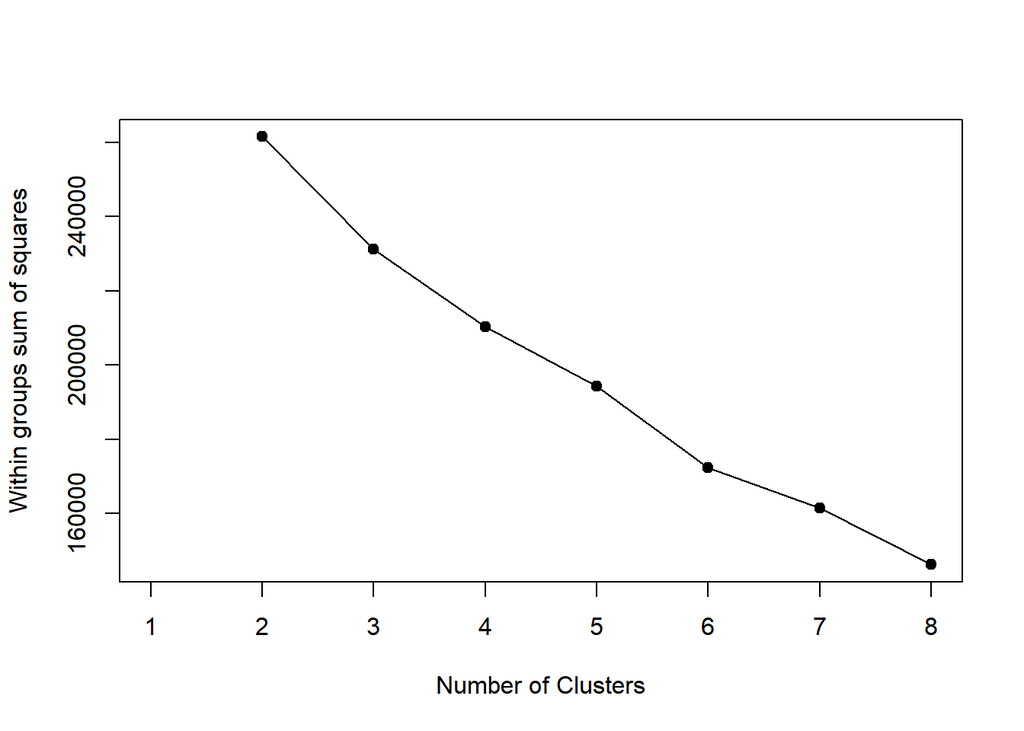

```r
wss <- function(data, maxCluster = 8) {
  SSw <- (nrow(data) - 1) * sum(apply(data, 2, var))
  SSw <- vector()
  for (i in 2:maxCluster) {
    SSw[i] <- sum(kmeans(data, centers = i)$withinss)
  }
  plot(1:maxCluster, SSw, type = "o", xlab = "Number of Clusters", ylab = "Within groups sum of squares", pch=19)
}

wss(tracks_artists_scaled)
```

K-means clustering:

Here we implement optimal K from our process before, we decided using K = 5

```r
tracks_artists_kmeans <- kmeans(tracks_artists_scaled, centers = 5)
tracks_artists_kmeans$centers
```

```
##   danceability     energy   loudness speechiness acousticness instrumentalness
## 1  -0.50404892  0.7177782  0.5194628 -0.04366033   -0.7671772       0.09259491
## 2  -0.05623102  0.4410477  0.1775721  1.55870755    0.1672319      -0.32826170
## 3  -0.12118255 -0.9914983 -0.4281079 -0.29695249    1.0384551      -0.31541735
## 4   0.79113668  0.3119214  0.3181680  0.01250273   -0.3612833      -0.28636787
## 5  -1.22379583 -1.7258141 -2.2706080 -0.33442285    1.5296964       1.94365990
##      liveness     valence       tempo
## 1 -0.04116029 -0.54791115  0.45539410
## 2  2.88210220  0.04685541 -0.10260233
## 3 -0.27290294 -0.27552816 -0.25298218
## 4 -0.24317650  0.87587392 -0.06937436
## 5 -0.32324597 -1.11566722 -0.61514071
```

```r
tracks_artists$cluster <- tracks_artists_kmeans$cluster
tracks_artists_kmeans
```

```
## K-means clustering with 5 clusters of sizes 10997, 2345, 7789, 13112, 3068
##
## Cluster means:
##   danceability     energy   loudness speechiness acousticness instrumentalness
## 1  -0.50404892  0.7177782  0.5194628 -0.04366033   -0.7671772       0.09259491
## 2  -0.05623102  0.4410477  0.1775721  1.55870755    0.1672319      -0.32826170
## 3  -0.12118255 -0.9914983 -0.4281079 -0.29695249    1.0384551      -0.31541735
## 4   0.79113668  0.3119214  0.3181680  0.01250273   -0.3612833      -0.28636787
## 5  -1.22379583 -1.7258141 -2.2706080 -0.33442285    1.5296964       1.94365990
##      liveness     valence       tempo
## 1 -0.04116029 -0.54791115  0.45539410
## 2  2.88210220  0.04685541 -0.10260233
## 3 -0.27290294 -0.27552816 -0.25298218
## 4 -0.24317650  0.87587392 -0.06937436
## 5 -0.32324597 -1.11566722 -0.61514071
```

[output cut: 1048 more lines]

```r
tracks_artists_kmeans$size
```

```
## [1] 10997  2345  7789 13112  3068
```

Goodness of fit:

Between Sum of Squares betweenss : signifies the ‘length’ from each centroid from each cluster to the global sample mean.

```r
bss.totss <- ((tracks_artists_kmeans$betweenss)/(tracks_artists_kmeans$totss))*100

cat('\n\n# Value for BSS / totss ratio, is `', bss.totss, '`\n\n')
```

```
##
##
## # Value for BSS / totss ratio, is ` 44.3332 `
```

- From the unsupervised learning analysis above, we can summarize that K-means clustering can be done using this data set since we have got a reasonable high value for BSS / totss ratio.
- We can repeat the same exercise multiple times by adjusting with multiple combinations of variables, to get the best fit and optimized model.

## Create and visualize Cluster plot

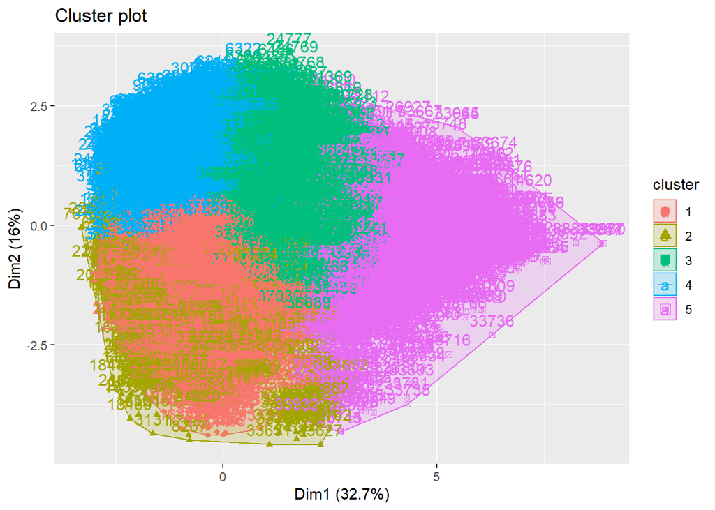

```r
tracks_artists_cluster <- fviz_cluster(tracks_artists_kmeans, data=tracks_artists_scaled)
tracks_artists_cluster
```

An efficient way to see how a cluster is different from its neighbour is to focus on dimensions or columns which vary the most. One way of obtaining the most varying columns is to take the result of PCA. The PCA effectively retains the dimension which vary the most and compresses the dimensions which vary the least.

Finding what kind of songs each cluster has in the optimized model:

```r
tracks_artists %>%
  group_by(cluster) %>%
  summarise_all(mean) %>%
  select(cluster, acousticness, danceability, energy, instrumentalness, speechiness, valence, liveness)
```

```
## # A tibble: 5 x 8
##   cluster acousticness danceability energy instrumentalness speechiness valence
##     <int>        <dbl>        <dbl>  <dbl>            <dbl>       <dbl>   <dbl>
## 1       1       0.0549        0.469  0.818           0.203       0.0828   0.321
## 2       2       0.371         0.549  0.747           0.0680      0.268    0.478
## 3       3       0.665         0.538  0.378           0.0721      0.0536   0.393
## 4       4       0.192         0.702  0.714           0.0814      0.0893   0.697
## 5       5       0.831         0.339  0.189           0.795       0.0493   0.171
## # ... with 1 more variable: liveness <dbl>
```

## Song Recommendations

We can try to recommend songs based of clusters we have formed. However, PCA can bring a lot of improvement in distinguishing different clusters going forward.

```r
tracks_artists %>%
  filter(cluster == 4, release_year == 2019) %>%
  arrange(desc(track_popularity)) %>%
top_n(20)
```

```
## # A tibble: 1,439 x 25
##    track_id track_name track_popularity release_year danceability energy key
##    <chr>    <chr>                 <dbl>        <dbl>        <dbl>  <dbl> <fct>
##  1 6UelLqG~ Watermelo~               94         2019        0.548  0.816 0
##  2 3H7ihDc~ Breaking ~               92         2019        0.789  0.72  8
##  3 7B3z0yS~ Sofia                    90         2019        0.744  0.619 0
##  4 2Fxmhks~ bad guy                  89         2019        0.701  0.425 7
##  5 7k4t7uL~ Tusa                     88         2019        0.803  0.715 2
##  6 3jjujdW~ Adore You                88         2019        0.676  0.771 8
##  7 2tnVG71~ Ride It                  87         2019        0.88   0.751 7
##  8 2wrJq5X~ 10,000 Ho~               86         2019        0.654  0.63  10
##  9 3Dv1eDb~ Say So                   86         2019        0.787  0.673 11
## 10 57RA3JG~ Are You B~               86         2019        0.682  0.683 8
## # ... with 1,429 more rows, and 18 more variables: loudness <dbl>, mode <fct>,
## #   speechiness <dbl>, acousticness <dbl>, instrumentalness <dbl>,
## #   liveness <dbl>, valence <dbl>, tempo <dbl>, time_signature <dbl>,
## #   duration_s <Duration>, artist_id <chr>, artist_name <chr>,
## #   artist_popularity <dbl>, total_followers <dbl>, artist_genre <fct>,
## #   duration_min <Duration>, popularity_group <int>, cluster <int>
```

# Regression Tree - Track popularity VS Audio features

```r
head(tracks)
```

```
## # A tibble: 6 x 18
##   track_id track_name track_popularity release_year danceability energy   key
##   <chr>    <chr>                 <dbl>        <dbl>        <dbl>  <dbl> <dbl>
## 1 1EzrEOX~ I'm Yours                83         2008        0.686  0.457    11
## 2 0IktbUc~ Lucky                    76         2008        0.623  0.417     0
## 3 53QF56c~ I Won't G~               73         2012        0.585  0.303     4
## 4 1s8tP3j~ 93 Millio~               53         2012        0.573  0.454     3
## 5 7BXW1QC~ Have It A~               66         2018        0.643  0.638     1
## 6 4XI5GjQ~ Look For ~               65         2020        0.71   0.615     0
## # ... with 11 more variables: loudness <dbl>, mode <dbl>, speechiness <dbl>,
## #   acousticness <dbl>, instrumentalness <dbl>, liveness <dbl>, valence <dbl>,
## #   tempo <dbl>, time_signature <dbl>, duration_s <Duration>, artist_id <chr>
```

```r
library(tree)
tree.audio = tree(track_popularity~. -track_id -track_name -release_year -artist_id -key+as.factor(key), tracks)
tree.audio
```

```
## node), split, n, deviance, yval
##       * denotes terminal node
##
## 1) root 37311 10810000 46.91
##   2) instrumentalness < 0.01385 25219  6732000 49.98
##     4) acousticness < 0.7085 21253  5249000 51.19 *
##     5) acousticness > 0.7085 3966  1286000 43.50 *
##   3) instrumentalness > 0.01385 12092  3340000 40.50 *
```

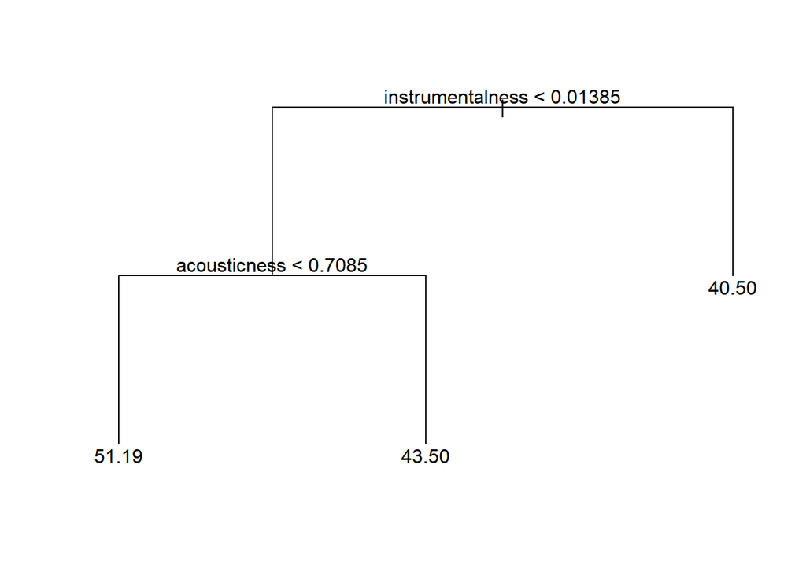

```r
plot(tree.audio,type="uniform")
text(tree.audio)
```

```r
summary(tree.audio)
```

```
##
## Regression tree:
## tree(formula = track_popularity ~ . - track_id - track_name -
##     release_year - artist_id - key + as.factor(key), data = tracks)
## Variables actually used in tree construction:
## [1] "instrumentalness" "acousticness"
## Number of terminal nodes:  3
## Residual mean deviance:  264.7 = 9874000 / 37310
## Distribution of residuals:
##    Min. 1st Qu.  Median    Mean 3rd Qu.    Max.
## -51.190  -9.185   1.499   0.000  11.500  52.500
```